# 2013 Bohol Earthquake

Erika Fille T. Legara

17/01/2017

## Background

In this `R` markdown document, we learn the basics of plotting points on a map using `maptools`—an `R` module that provides a set of tools pertinent to reading and handling spatial objects.

```r
library(maptools)
```

This code was originally written back in October 2013 [to visualize](https://erikafille.ph/2013/10/19/did-you-tweet-about-the-bohol-earthquake/) the disaster event, an earthquake, that hit the province of Bohol, Philippines.

#### The Datasets

We use two datasets in this notebook:

1. **The Map**.

   Format: `.rds`

   Source: [GADM](http://gadm.org/about) (Global Administrative Areas website).
2. **The Earthquake Dataset**. The earthquake dataset was downloaded on 18 October 2013.

   Format: `.csv`

   Source [USGS](https://www.usgs.gov/) (U.S. Geological Survey)

#### Data Exploration

##### The Map

We first load the `rds` map file `PHL_adm2.rds`. The number `2` in the `PHL_adm2.rds` indicates the administrative level of the dataset where `0` is the country level, `1` provincial level, `2` city level, and `3` for barangay level. Let’s load the dataset and store it in the variable `gadm`.

```r
gadm<-readRDS("../PH_GIS_Data/PHL_adm2.rds")
```

Let’s have a look at what’s inside the gadm data.

```r
names(gadm)
```

```
##  [1] "OBJECTID"  "ID_0"      "ISO"       "NAME_0"    "ID_1"
##  [6] "NAME_1"    "ID_2"      "NAME_2"    "HASC_2"    "CCN_2"
## [11] "CCA_2"     "TYPE_2"    "ENGTYPE_2" "NL_NAME_2" "VARNAME_2"
```

We can see that there are 15 columns/features in the dataset including `OBJECT_ID`, `NAME_0`, `NAME_1`, and `NAME_2`.

Below, we print out the first 10 entries under `NAME_0`, which provides the country. As expected, all entries give “Philippines”.

```r
print(gadm$NAME_0[0:10])
```

```
##  [1] "Philippines" "Philippines" "Philippines" "Philippines" "Philippines"
##  [6] "Philippines" "Philippines" "Philippines" "Philippines" "Philippines"
```

To list the different provinces for each entry, we look into the variable, `NAME_1`. Below is a list of the first 10 entries under `NAME_1`.

```
##  [1] "Abra" "Abra" "Abra" "Abra" "Abra" "Abra" "Abra" "Abra" "Abra" "Abra"
```

Finally, below is a list of the first 10 entries under `NAME_2`. These are the cities.

```
##  [1] "Bangued"     "Boliney"     "Bucay"       "Bucloc"      "Daguioman"
##  [6] "Danglas"     "Dolores"     "La Paz"      "Lacub"       "Lagangilang"
```

If we plot the whole of `PHL_adm2.rds`, we will see the entire map of the Philippines partitioned into cities. However, if we only want to focus on specific province or city, we can filter the entire dataset. For the purpose of this work, we introduce a variable named `bohol` (for Bohol province) and filter in all information where `NAME_1=="Bohol"`.

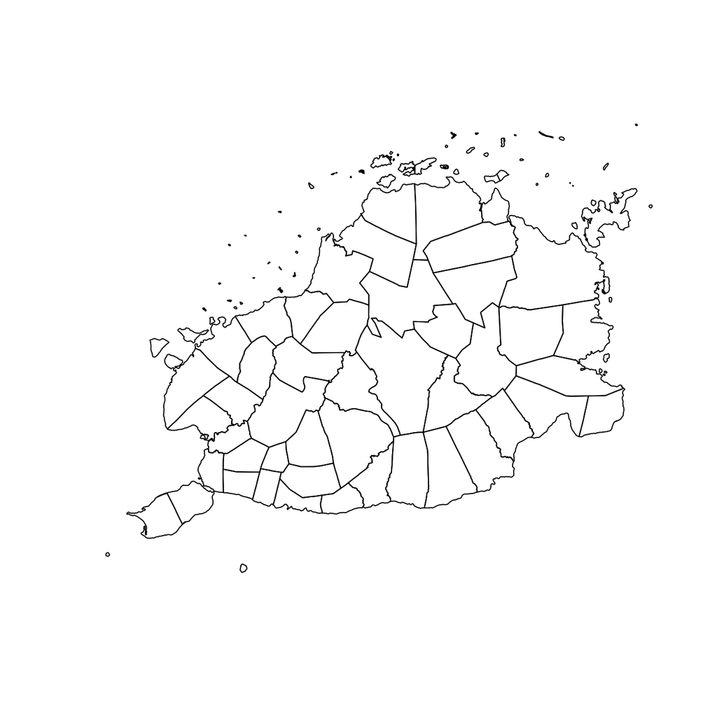

```r
bohol<-gadm[gadm$NAME_1=="Bohol",]
plot(bohol)
```

Similarly, if we want to focus on individual cities, like Catigbian, Bohol and Loon, Bohol, we use the variable `NAME_2` as filter.

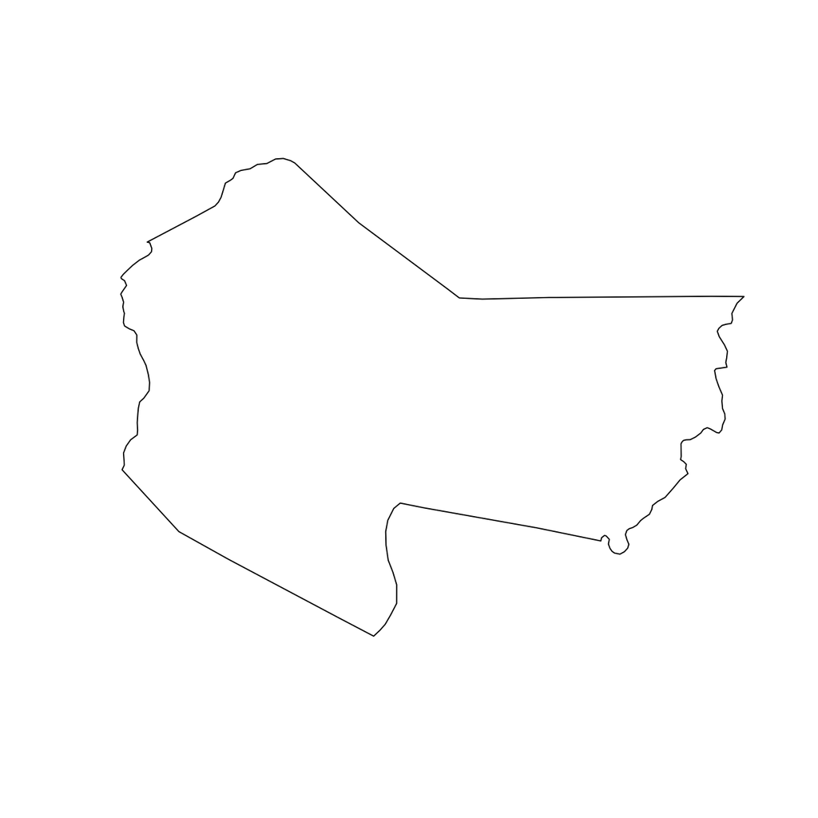

```r
catigbian<-bohol[bohol$NAME_2=="Catigbian",]
loon<-bohol[bohol$NAME_2=="Loon",]
plot(catigbian)
```

##### The Earthquake Data

Now, let’s have a look at the earthquake dataset that was downloaded last 18 October 2013 from the USGS earthquake database,

```r
quake<-read.csv('equake3.csv')
head(quake)
```

```
##       date nth hh mm    ss timeacross latitude longitude depth mag magType
## 1 17/10/13   7 15  6 51.00     659211  60.5161 -147.3904  19.7 2.0      Ml
## 2 17/10/13   7 15  0 33.30     658833  19.3207 -155.1912   1.8 2.6      Ml
## 3 17/10/13   7 14 18 48.20     656328  19.3752 -155.2802  33.6 2.3      Ml
## 4 17/10/13   7 13 45 10.60     654311  37.3892 -118.6773  13.2 3.1      Md
## 5 17/10/13   7 11 13 12.05     645192 -10.8982  165.9252  62.8 5.4      mb
## 6 17/10/13   7  8 52 39.00     636759  62.6175 -151.7809  49.2 2.0      Ml
##   nst   gap       dmin  rms net         id                  updated
## 1  20 144.0 0.38986883 0.88  ak ak10825751 2013-10-17T15:12:54.467Z
## 2  NA 100.8 0.05389892 0.35  hv hv60578296 2013-10-17T15:06:19.514Z
## 3  NA  50.4 0.00898315 0.20  hv hv60578286 2013-10-17T14:24:34.837Z
## 4  NA 108.0 0.06288207 0.05  nc nc72089491 2013-10-17T14:12:06.146Z
## 5  NA  59.0 6.06000000 0.99  us usb000kfhi 2013-10-17T11:30:39.000Z
## 6   5 187.2 1.01150301 0.84  ak ak10825672 2013-10-17T08:55:05.822Z
##                   place        country       type
## 1  76km ESE of Whittier         Alaska earthquake
## 2   13km SSE of Volcano         Hawaii earthquake
## 3     7km SW of Volcano         Hawaii earthquake
## 4 19km W of West Bishop     California earthquake
## 5      22km SSE of Lata SolomonIslands earthquake
## 6 92km WNW of Talkeetna         Alaska earthquake
```

Since, we are only interested in the earthquake event that happened in the Philippines from October 15-17, 2013, we can filter the dataset accordingly.

```r
quake<-quake[quake$country=="Philippines",]
quake$date <- as.Date(quake$date, format="%d/%m/%y")
quake <- quake[quake$date >= as.Date("2013-10-15") & quake$date <= as.Date("2013-10-17"),]
head(quake)
```

```
##          date nth hh mm    ss timeacross latitude longitude depth mag
## 11 2013-10-17   7  5 46  4.37     625564  10.0040  124.1070 20.22 4.7
## 24 2013-10-16   6 23 37 33.10     603453   9.7624  123.8588 35.22 5.3
## 26 2013-10-16   6 22 19 13.50     598754   9.9535  124.0062 22.35 4.9
## 41 2013-10-16   6 15 32 45.65     574366   9.5789  123.7170 20.55 4.9
## 43 2013-10-16   6 15  8 27.77     572908   9.6423  123.6263 20.33 5.2
## 55 2013-10-16   6  9 56 56.18     554216   9.9575  124.1094 19.73 5.0
##    magType nst gap  dmin  rms net         id                  updated
## 11      mb  NA  99 3.258 1.00  us usb000kfg7 2013-10-17T08:23:07.000Z
## 24      mb  NA 117 3.170 1.08  us usb000kfbv 2013-10-17T06:14:43.356Z
## 26      mb  NA  66 3.260 0.74  us usb000kfad 2013-10-17T01:43:13.370Z
## 41      mb  NA  86 3.100 0.91  us usb000kesc 2013-10-16T17:16:29.000Z
## 43      mb  NA  76 3.204 0.73  us usb000keru 2013-10-17T00:38:40.279Z
## 55      mb  NA 111 3.216 0.85  us usb000kely 2013-10-16T10:13:09.000Z
##                     place     country       type
## 11     5km SE of Inabanga Philippines earthquake
## 24    2km NE of Maribojoc Philippines earthquake
## 26      2km WSW of Clarin Philippines earthquake
## 41        1km SW of Duljo Philippines earthquake
## 43      12km WNW of Duljo Philippines earthquake
## 55 2km NE of Canmaya Diot Philippines earthquake
```

#### Plotting

Finally, we plot these earthquake datapoints onto the map of Bohol. Notice below that we’re converting the date column of the data frame `quake` to `factor` class (from `date` class). It’s for ease of plotting since we want to color the datapoints according to the day they occurred.

```r
quake$date <- as.factor(quake$date)
```

Let’s also define a variable `malakas` to extract the earthquake entrywith the maximum/greatest magnitude from our filtered data frame.

```r
malakas = quake[quake$mag==max(quake$mag),]
print(malakas)
```

```
##           date nth hh mm   ss timeacross latitude longitude depth mag
## 166 2013-10-15   5  0 12 32.9     432753   9.8662  124.0115    20 7.1
##     magType nst gap  dmin  rms net         id                  updated
## 166     mww  NA  25 3.181 1.12  us usb000kdb4 2013-10-17T15:18:42.918Z
##                   place     country       type
## 166 2km NE of Catigbian Philippines earthquake
```

According to USGS records, the strongest magnitude (7.1) hit location `{lat: 9.8662, lon: 124.0115}`, which is `2km NE of Catigbian`, on 15 October 2013. In the plot below, we highlight the city of Catigbian (yellow).

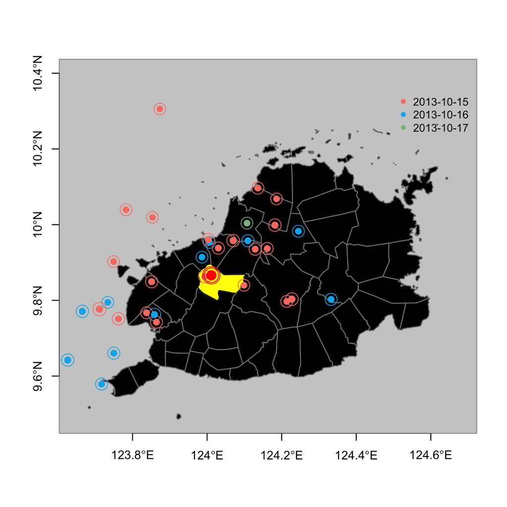

```r
plot(bohol, axes=T, border='gray50', bg='gray80', col='black', lwd=1.3,
     xlim=c(123.68114,124.64547), ylim=c(9.48583, 10.4))
par(new=TRUE)
plot(catigbian, col="yellow", xlim=c(123.68114,124.64547), ylim=c(9.48583, 10.4),
     bg="transparent")
colors <- c("salmon", "deepskyblue2", "darkseagreen")
points(quake$longitude,quake$latitude, col=colors[quake$date], pch=1, cex = sqrt(quake$mag))
points(quake$longitude,quake$latitude, col=colors[quake$date], pch=16, cex = sqrt(quake$mag/pi))
points(malakas$longitude,malakas$latitude, col='red', pch=16, cex = sqrt(malakas$mag/2))
points(malakas$longitude,malakas$latitude, col='red', pch=1, cex = sqrt(malakas$mag))
points(malakas$longitude,malakas$latitude, col='red', pch=1, cex = 1.2*sqrt(malakas$mag))
legend(124.5,10.36, legend = levels(quake$date), col=colors, cex = 0.9, pch = 16, bty = "n")
```